# Trading Strategy MACD

Moving Average Convergence Divergence or MACD was developed by Gerald Appel in the late seventies. It is one of the simplest and effective trend-following momentum indicators.

In MACD strategy, we use two series, MACD series which is the difference between the 26-day EMA and 12-day EMA and signal series which is the 9 day EMA of MACD series.

We can trigger the trading signal using MACD series and signal series.

When the MACD line crosses above the signal line, then it is recommended to buy the underlying security. When the MACD line crosses below the signal line, then a signal to sell is triggered.

```python
# Import yfinance
import yfinance as yf


data = yf.download('AAPL', start="2007-01-01", end="2010-01-01")

# Print the first five rows of the data
data.head()
```

```
[*********************100%***********************]  1 of 1 completed
```

| Date | Open | High | Low | Close | Adj Close | Volume |
| --- | --- | --- | --- | --- | --- | --- |
| 2007-01-03 | 12.327143 | 12.368571 | 11.700000 | 11.971429 | 10.391690 | 309579900 |
| 2007-01-04 | 12.007143 | 12.278571 | 11.974286 | 12.237143 | 10.622340 | 211815100 |
| 2007-01-05 | 12.252857 | 12.314285 | 12.057143 | 12.150000 | 10.546695 | 208685400 |
| 2007-01-08 | 12.280000 | 12.361428 | 12.182858 | 12.210000 | 10.598778 | 199276700 |
| 2007-01-09 | 12.350000 | 13.282857 | 12.164286 | 13.224286 | 11.479221 | 837324600 |

We can trigger the trading signal using MACD series and signal series.

When the MACD line crosses above the signal line, then it is recommended to buy the underlying security. When the MACD line crosses below the signal line, then a signal to sell is triggered.

```python
# Import matplotlib
import matplotlib.pyplot as plt
import pandas as pd
plt.style.use('ggplot')
```

```python
data.index = pd.to_datetime(data.index, dayfirst=True)
```

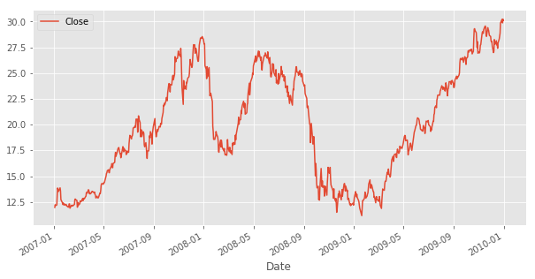

```python
# Visualise the data
plt.figure(figsize=(10,5))
data['Close'].plot(figsize=(10,5))
plt.legend()
plt.show()
```

Calculate and plot the MACD series which is the difference 26-day EMA and 12-day EMA and signal series which is 9 day EMA of the MACD series.

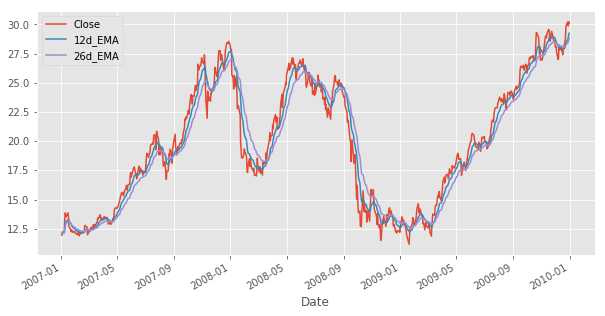

```python
# Calculate exponential moving average
data['12d_EMA'] = data.Close.ewm(span=12).mean()
data['26d_EMA'] = data.Close.ewm(span=26).mean()

data[['Close','12d_EMA','26d_EMA']].plot(figsize=(10,5))
plt.show()
```

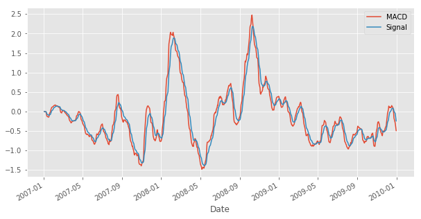

```python
# Calculate MACD
data['MACD'] = data['26d_EMA'] - data['12d_EMA']

# Calculate Signal
data['Signal'] = data.MACD.ewm(span=9).mean()

data[['MACD','Signal']].plot(figsize=(10,5))
plt.show()
```

### Create a trading signal

When the value of MACD series is greater than signal series then buy, else sell.

```python
 #Import numpy
import numpy as np

# Define Signal
data['trading_signal'] = np.where(data['MACD'] > data['Signal'], 1, -1)
```

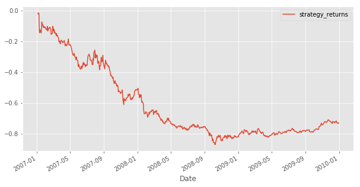

```python
# Calculate Returns
data['returns'] = data.Close.pct_change()

# Calculate Strategy Returns
data['strategy_returns'] = data.returns * data.trading_signal.shift(1)

# Calculate Cumulative Returns
cumulative_returns = (data.strategy_returns + 1).cumprod()-1

# Plot Strategy Returns
cumulative_returns.plot(figsize=(10,5))
plt.legend()
plt.show()
```

```python
# 1. Annualised Return or Compound Annual Growth Rate (CAGR)

# Total number of trading days in a year is 252
trading_days = 252

# Calculate CAGR by multiplying the average daily returns with number of trading days
annual_returns = ((1 + data.returns.mean())**(trading_days) - 1)*100
```

```python
'The CAGR is %.2f%%' % annual_returns
```

```
'The CAGR is 50.46%'
```

```python
# 2. Annualised Volatility

# Calculate the annualised volatility
annual_volatility = data.returns.std() * np.sqrt(trading_days) * 100
'The annualised volatility is %.2f%%' % annual_volatility
```

```
'The annualised volatility is 44.82%'
```

```python
# 3. Sharpe Ratio
# Assume the annual risk-free rate is 2.5%
risk_free_rate = 0.025
daily_risk_free_return = risk_free_rate/trading_days

# Calculate the excess returns by subtracting the daily returns by daily risk-free return
excess_daily_returns = data.returns - daily_risk_free_return

# Calculate the sharpe ratio using the given formula
sharpe_ratio = (excess_daily_returns.mean() /
                excess_daily_returns.std()) * np.sqrt(trading_days)
'The Sharpe ratio is %.2f' % sharpe_ratio
```

[output not shown]

```python
# Import yfinance
import yfinance as yf


data = yf.download('AAPL', start="2010-01-01", end="2020-01-01")

# Print the first five rows of the data
data.head()
```

```
[*********************100%***********************]  1 of 1 completed
```

| Date | Open | High | Low | Close | Adj Close | Volume |
| --- | --- | --- | --- | --- | --- | --- |
| 2010-01-04 | 30.490000 | 30.642857 | 30.340000 | 30.572857 | 26.538483 | 123432400 |
| 2010-01-05 | 30.657143 | 30.798571 | 30.464285 | 30.625713 | 26.584366 | 150476200 |
| 2010-01-06 | 30.625713 | 30.747143 | 30.107143 | 30.138571 | 26.161509 | 138040000 |
| 2010-01-07 | 30.250000 | 30.285715 | 29.864286 | 30.082857 | 26.113146 | 119282800 |
| 2010-01-08 | 30.042856 | 30.285715 | 29.865715 | 30.282858 | 26.286753 | 111902700 |

```python
# Import matplotlib
import matplotlib.pyplot as plt
import pandas as pd
plt.style.use('ggplot')
```

```python
 data.index = pd.to_datetime(data.index, dayfirst=True)
```

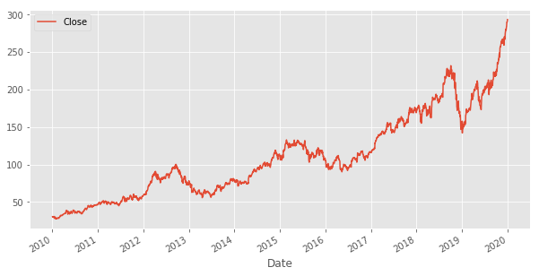

```python
# Visualise the data
plt.figure(figsize=(10,5))
data['Close'].plot(figsize=(10,5))
plt.legend()
plt.show()
```

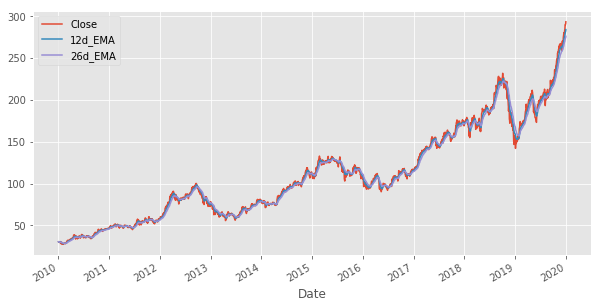

```python
# Calculate exponential moving average
data['12d_EMA'] = data.Close.ewm(span=12).mean()
data['26d_EMA'] = data.Close.ewm(span=26).mean()

data[['Close','12d_EMA','26d_EMA']].plot(figsize=(10,5))
plt.show()
```

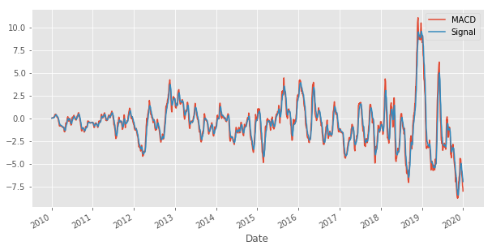

```python
# Calculate MACD
data['MACD'] = data['26d_EMA'] - data['12d_EMA']

# Calculate Signal
data['Signal'] = data.MACD.ewm(span=9).mean()

data[['MACD','Signal']].plot(figsize=(10,5))
plt.show()
```

## Create a trading signal

When the value of MACD series is greater than signal series then buy, else sell.

```python
 #Import numpy
import numpy as np

# Define Signal
data['trading_signal'] = np.where(data['MACD'] > data['Signal'], 1, -1)
```

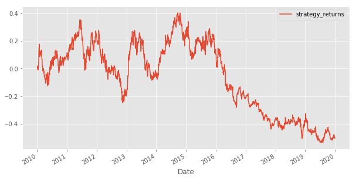

```python
# Calculate Returns
data['returns'] = data.Close.pct_change()

# Calculate Strategy Returns
data['strategy_returns'] = data.returns * data.trading_signal.shift(1)

# Calculate Cumulative Returns
cumulative_returns = (data.strategy_returns + 1).cumprod()-1

# Plot Strategy Returns
cumulative_returns.plot(figsize=(10,5))
plt.legend()
plt.show()
```

```python
# 1. Annualised Return or Compound Annual Growth Rate (CAGR)

# Total number of trading days in a year is 252
trading_days = 252

# Calculate CAGR by multiplying the average daily returns with number of trading days
annual_returns = ((1 + data.returns.mean())**(trading_days) - 1)*100
```

```python
'The CAGR is %.2f%%' % annual_returns
```

```
'The CAGR is 29.68%'
```

```python
# 2. Annualised Volatility

# Calculate the annualised volatility
annual_volatility = data.returns.std() * np.sqrt(trading_days) * 100
'The annualised volatility is %.2f%%' % annual_volatility
```

```
'The annualised volatility is 25.77%'
```

```python
# 3. Sharpe Ratio
# Assume the annual risk-free rate is 2.5%
risk_free_rate = 0.025
daily_risk_free_return = risk_free_rate/trading_days

# Calculate the excess returns by subtracting the daily returns by daily risk-free return
excess_daily_returns = data.returns - daily_risk_free_return

# Calculate the sharpe ratio using the given formula
sharpe_ratio = (excess_daily_returns.mean() /
                excess_daily_returns.std()) * np.sqrt(trading_days)
'The Sharpe ratio is %.2f' % sharpe_ratio
```

```
'The Sharpe ratio is 0.91'
```